# Part 2

1. Describe the data and the problem

```r
library(readr)
library(assertr)
library(tidyverse)
library(lubridate)
library(janitor)
```

Problem: Given a list of users along with their demographics, web session records, and some summary statistics, we can build a model to predict Airbnb user destination for first booking.

All the users in this dataset are from the USA.

```r
dest <- read_csv("train_users_2.csv")
dest <- dest %>% clean_names()
```

```r
dim(dest)
```

```
[1] 213451     16
```

The training data had the demographic and session information for 213451 users. It contains 16 variables in this data set.

```r
names(dest)
```

```
 [1] "id"                      "date_account_created"    "timestamp_first_active"
 [4] "date_first_booking"      "gender"                  "age"
 [7] "signup_method"           "signup_flow"             "language"
[10] "affiliate_channel"       "affiliate_provider"      "first_affiliate_tracked"
[13] "signup_app"              "first_device_type"       "first_browser"
[16] "country_destination"
```

date_account_created: the date of account creation

timestamp_first_active: timestamp of the first activity, note that it can be earlier than date_account_created or date_first_booking because a user can search before signing up

date_first_booking: date of first booking

signup_flow: the page a user came to signup up from

language: international language preference

affiliate_channel: what kind of paid marketing

affiliate_provider: where the marketing is e.g. google, craigslist, other

first_affiliate_tracked: whats the first marketing the user interacted with before the signing up

country_destination: the target variable to predict

```r
dest %>%
  distinct(first_device_type)
```

| first_device_type |
| --- |
| Mac Desktop |
| Windows Desktop |
| iPhone |
| Other/Unknown |
| Desktop (Other) |
| Android Tablet |
| iPad |
| Android Phone |
| SmartPhone (Other) |

Users can use the web application or the android/iOS application.

```r
dest %>%
  distinct(signup_method)
```

| signup_method |
| --- |
| facebook |
| basic |
| google |

User can sign up via facebook, goole account or basic method.

```r
dest %>%
  distinct(country_destination)
```

| country_destination |
| --- |
| NDF |
| US |
| other |
| FR |
| CA |
| GB |
| ES |
| IT |
| PT |
| NL |

[output cut: 2 more lines]

There are 12 possible outcomes of the destination country: ‘US’-USA, ‘FR’-France, ‘CA’-Canada, ‘GB’-Great Britain, ‘ES’-Spain, ‘IT’-Italy, ‘PT’-Portugal, ‘NL’-Netherlands,‘DE’-Denmark, ‘AU’-Australia, ‘NDF’ (no destination found), and ‘other’.

‘NDF’ is different from ‘other’ because ‘other’ means there was a booking, but is to a country not included in the list, while ‘NDF’ means there wasn’t a booking.

2. Read in and check data

**Data Type for Each Column**

we could check the data type for each column using head()

```r
head(dest)
```

| id | date_account_created | timestamp_first_active | date_first_booking | gender | age | signup_method | signup_flow | language | affiliate_channel | affiliate_provider | first_affiliate_tracked | signup_app | first_device_type | first_browser | country_destination |
| --- | --- | --- | --- | --- | --- | --- | --- | --- | --- | --- | --- | --- | --- | --- | --- |
| gxn3p5htnn | 2010-06-28 | 2.009032e+13 |  | -unknown- | NA | facebook | 0 | en | direct | direct | untracked | Web | Mac Desktop | Chrome | NDF |
| 820tgsjxq7 | 2011-05-25 | 2.009052e+13 |  | MALE | 38 | facebook | 0 | en | seo | google | untracked | Web | Mac Desktop | Chrome | NDF |
| 4ft3gnwmtx | 2010-09-28 | 2.009061e+13 | 2010-08-02 | FEMALE | 56 | basic | 3 | en | direct | direct | untracked | Web | Windows Desktop | IE | US |
| bjjt8pjhuk | 2011-12-05 | 2.009103e+13 | 2012-09-08 | FEMALE | 42 | facebook | 0 | en | direct | direct | untracked | Web | Mac Desktop | Firefox | other |
| 87mebub9p4 | 2010-09-14 | 2.009121e+13 | 2010-02-18 | -unknown- | 41 | basic | 0 | en | direct | direct | untracked | Web | Mac Desktop | Chrome | US |
| osr2jwljor | 2010-01-01 | 2.010010e+13 | 2010-01-02 | -unknown- | NA | basic | 0 | en | other | other | omg | Web | Mac Desktop | Chrome | US |

**gender**

```r
dest %>%
  distinct(gender)
```

| gender |
| --- |
| -unknown- |
| MALE |
| FEMALE |
| OTHER |

For “-unknown”, it should be considered as missing values in gender

**date_first_booking**

```r
dest %>%
  verify(!is.na(date_first_booking))
```

```
verification [!is.na(date_first_booking)] failed! (124543 failures)
```

| verb | redux_fn | predicate | column | index | value |
| --- | --- | --- | --- | --- | --- |
| verify | NA | !is.na(date_first_booking) | NA | 1 | NA |
| verify | NA | !is.na(date_first_booking) | NA | 2 | NA |
| verify | NA | !is.na(date_first_booking) | NA | 12 | NA |
| verify | NA | !is.na(date_first_booking) | NA | 14 | NA |
| verify | NA | !is.na(date_first_booking) | NA | 15 | NA |
| verify | NA | !is.na(date_first_booking) | NA | 17 | NA |
| verify | NA | !is.na(date_first_booking) | NA | 19 | NA |
| verify | NA | !is.na(date_first_booking) | NA | 24 | NA |
| verify | NA | !is.na(date_first_booking) | NA | 25 | NA |
| verify | NA | !is.na(date_first_booking) | NA | 27 | NA |

[output cut: 990 more lines]

```
Error: assertr stopped execution
```

There are 124,543 NA in date_first_booking. Thus, about 58% users didn’t book a trip to any destination yet.

```r
dest %>%
  filter(country_destination=="NDF")
```

| id | date_account_created | timestamp_first_active | date_first_booking | gender | age | signup_method | signup_flow | language | affiliate_channel | affiliate_provider | first_affiliate_tracked | signup_app | first_device_type | first_browser | country_destination |
| --- | --- | --- | --- | --- | --- | --- | --- | --- | --- | --- | --- | --- | --- | --- | --- |
| gxn3p5htnn | 2010-06-28 | 2.009032e+13 |  | -unknown- | NA | facebook | 0 | en | direct | direct | untracked | Web | Mac Desktop | Chrome | NDF |
| 820tgsjxq7 | 2011-05-25 | 2.009052e+13 |  | MALE | 38 | facebook | 0 | en | seo | google | untracked | Web | Mac Desktop | Chrome | NDF |
| om1ss59ys8 | 2010-01-05 | 2.010011e+13 |  | FEMALE | 47 | basic | 0 | en | other | craigslist | untracked | Web | iPhone | -unknown- | NDF |
| dy3rgx56cu | 2010-01-05 | 2.010011e+13 |  | FEMALE | 37 | basic | 0 | en | other | craigslist | linked | Web | Mac Desktop | Firefox | NDF |
| ju3h98ch3w | 2010-01-07 | 2.010011e+13 |  | FEMALE | 36 | basic | 0 | en | other | craigslist | untracked | Web | iPhone | Mobile Safari | NDF |
| 2dwbwkx056 | 2010-01-07 | 2.010011e+13 |  | -unknown- | NA | basic | 0 | en | other | craigslist | NA | Web | Other/Unknown | -unknown- | NDF |
| cxlg85pg1r | 2010-01-08 | 2.010011e+13 |  | -unknown- | NA | basic | 0 | en | seo | facebook | NA | Web | Other/Unknown | -unknown- | NDF |
| jha93x042q | 2010-01-11 | 2.010011e+13 |  | -unknown- | NA | basic | 0 | en | other | craigslist | untracked | Web | Mac Desktop | Safari | NDF |
| 7i49vnuav6 | 2010-01-11 | 2.010011e+13 |  | FEMALE | 40 | basic | 0 | en | seo | google | untracked | Web | Mac Desktop | Firefox | NDF |
| bjg0m5otl3 | 2010-01-12 | 2.010011e+13 |  | -unknown- | NA | basic | 0 | en | other | other | untracked | Web | Other/Unknown | -unknown- | NDF |

[output cut: 990 more lines]

The number of users whose country destination is “NDF” is 124543, which is consistent with NA in date_first_booking. Thus, in the predict problem, we could predict all destinations to be NDF if data_first_booking is NA.

**age**

```r
dest %>%
  verify(!is.na(age))
```

```
verification [!is.na(age)] failed! (87990 failures)
```

| verb | redux_fn | predicate | column | index | value |
| --- | --- | --- | --- | --- | --- |
| verify | NA | !is.na(age) | NA | 1 | NA |
| verify | NA | !is.na(age) | NA | 6 | NA |
| verify | NA | !is.na(age) | NA | 13 | NA |
| verify | NA | !is.na(age) | NA | 17 | NA |
| verify | NA | !is.na(age) | NA | 19 | NA |
| verify | NA | !is.na(age) | NA | 21 | NA |
| verify | NA | !is.na(age) | NA | 24 | NA |
| verify | NA | !is.na(age) | NA | 27 | NA |
| verify | NA | !is.na(age) | NA | 39 | NA |
| verify | NA | !is.na(age) | NA | 44 | NA |

[output cut: 990 more lines]

```
Error: assertr stopped execution
```

There are 87990 missing values in age.

```r
dest %>%
  assert(within_bounds(0,120), age)
```

```
Column 'age' violates assertion 'within_bounds(0, 120)' 781 times
```

|  | verb | redux_fn | predicate | column | index | value |
| --- | --- | --- | --- | --- | --- | --- |
| 1 | assert | NA | within_bounds(0, 120) | age | 389 | 2014 |
| 2 | assert | NA | within_bounds(0, 120) | age | 674 | 2014 |
| 3 | assert | NA | within_bounds(0, 120) | age | 1041 | 2014 |
| 4 | assert | NA | within_bounds(0, 120) | age | 1178 | 2013 |
| 5 | assert | NA | within_bounds(0, 120) | age | 1201 | 2014 |

```
  [omitted 776 rows]
```

```
Error: assertr stopped execution
```

There are 781 extreme values in age. It is possible that people put their year of birth instead of their age.

3. Clean up the data.

**timestamp_first_active**

we can transform timestamp to POSIXct objects

```r
dest <- dest %>%
  mutate(timestamp_first_active=ymd_hms(as.character(dest$timestamp_first_active)))
```

**gender**

change all the “-unknown” in gender to NA

```r
dest <- dest %>%
  mutate(gender=ifelse(gender=="-unknown-",NA,gender))
```

**signup method**

change signup method to factor and convert from category to numeric

```r
dest <- dest %>%
  mutate(signup_method =factor(signup_method,labels=1:3))
```

Thus, in the factor, basic is set to be 1, facebook is set to be 2 and google is set to be 3

**language**

change language to factor

```r
dest <- dest %>%
  mutate(language =factor(language))
```

**first browser**

change all the “-unknown-” in first browser to NA

```r
dest <- dest %>%
  mutate(first_browser=ifelse(first_browser=="-unknown-",NA,first_browser))
```

**country destination**

change country_destination to factor

```r
dest <- dest %>%
  mutate(country_destination =factor(country_destination))
```

*Note: You may request that score for these sections replace your score for the coding portion of Assignment 3.*

4. Using best practices, write four functions which add engineered features to the dataset, including a description and rationale. Include a test to determine whether the features are working as intended.

**function 1**

Given a month, some countries are more likely to be visited owing to seasonality in terms of weather/festivals. The travel destination for different countries could depend on the month. Given a month, some countries are more likely to be visited owing to seasonality in terms of weather/festivals.

```r
calc_month <- function (df,var) {
  df %>%
    mutate(month=months({{var}}))
}
#test
dest %>%
  calc_month(date_first_booking) %>%
  select(date_first_booking,month,everything())
```

| date_first_booking | month | id | date_account_created | timestamp_first_active | gender | age | signup_method | signup_flow | language | affiliate_channel | affiliate_provider | first_affiliate_tracked | signup_app | first_device_type | first_browser | country_destination |
| --- | --- | --- | --- | --- | --- | --- | --- | --- | --- | --- | --- | --- | --- | --- | --- | --- |
|  | NA | gxn3p5htnn | 2010-06-28 | 2009-03-19 04:32:55 | NA | NA | 2 | 0 | en | direct | direct | untracked | Web | Mac Desktop | Chrome | NDF |
|  | NA | 820tgsjxq7 | 2011-05-25 | 2009-05-23 17:48:09 | MALE | 38 | 2 | 0 | en | seo | google | untracked | Web | Mac Desktop | Chrome | NDF |
| 2010-08-02 | August | 4ft3gnwmtx | 2010-09-28 | 2009-06-09 23:12:47 | FEMALE | 56 | 1 | 3 | en | direct | direct | untracked | Web | Windows Desktop | IE | US |
| 2012-09-08 | September | bjjt8pjhuk | 2011-12-05 | 2009-10-31 06:01:29 | FEMALE | 42 | 2 | 0 | en | direct | direct | untracked | Web | Mac Desktop | Firefox | other |
| 2010-02-18 | February | 87mebub9p4 | 2010-09-14 | 2009-12-08 06:11:05 | NA | 41 | 1 | 0 | en | direct | direct | untracked | Web | Mac Desktop | Chrome | US |
| 2010-01-02 | January | osr2jwljor | 2010-01-01 | 2010-01-01 21:56:19 | NA | NA | 1 | 0 | en | other | other | omg | Web | Mac Desktop | Chrome | US |
| 2010-01-05 | January | lsw9q7uk0j | 2010-01-02 | 2010-01-02 01:25:58 | FEMALE | 46 | 1 | 0 | en | other | craigslist | untracked | Web | Mac Desktop | Safari | US |
| 2010-01-13 | January | 0d01nltbrs | 2010-01-03 | 2010-01-03 19:19:05 | FEMALE | 47 | 1 | 0 | en | direct | direct | omg | Web | Mac Desktop | Safari | US |
| 2010-07-29 | July | a1vcnhxeij | 2010-01-04 | 2010-01-04 00:42:11 | FEMALE | 50 | 1 | 0 | en | other | craigslist | untracked | Web | Mac Desktop | Safari | US |
| 2010-01-04 | January | 6uh8zyj2gn | 2010-01-04 | 2010-01-04 02:37:58 | NA | 46 | 1 | 0 | en | other | craigslist | omg | Web | Mac Desktop | Firefox | US |

[output cut: 990 more lines]

**function 2**

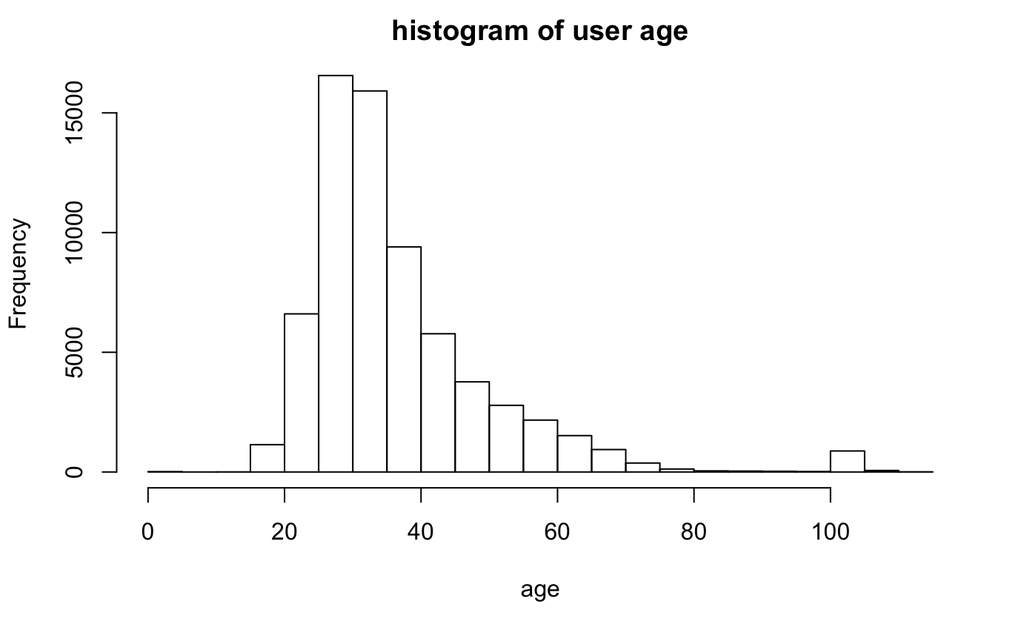

```r
dest_new <- dest[!is.na(dest$date_first_booking) & dest$age<120 & !is.na(dest$age),]
hist(dest_new$age,xlab="age",main="histogram of user age")
```

From this histogram, we could see that most user that actually booked a trip is under 40, thus we could add a dummy variable to indicate if the age is under 40 or not. Let 1 be age under 40 and 0 be age above 40.

```r
age_dummy <- function (df,var) {
  df %>%
    mutate(age_under_40=as.integer({{var}} <=40))
}
#test
dest %>%
  age_dummy(age) %>%
  select(age,age_under_40,everything())
```

| age | age_under_40 | id | date_account_created | timestamp_first_active | date_first_booking | gender | signup_method | signup_flow | language | affiliate_channel | affiliate_provider | first_affiliate_tracked | signup_app | first_device_type | first_browser | country_destination |
| --- | --- | --- | --- | --- | --- | --- | --- | --- | --- | --- | --- | --- | --- | --- | --- | --- |
| NA | NA | gxn3p5htnn | 2010-06-28 | 2009-03-19 04:32:55 |  | NA | 2 | 0 | en | direct | direct | untracked | Web | Mac Desktop | Chrome | NDF |
| 38 | 1 | 820tgsjxq7 | 2011-05-25 | 2009-05-23 17:48:09 |  | MALE | 2 | 0 | en | seo | google | untracked | Web | Mac Desktop | Chrome | NDF |
| 56 | 0 | 4ft3gnwmtx | 2010-09-28 | 2009-06-09 23:12:47 | 2010-08-02 | FEMALE | 1 | 3 | en | direct | direct | untracked | Web | Windows Desktop | IE | US |
| 42 | 0 | bjjt8pjhuk | 2011-12-05 | 2009-10-31 06:01:29 | 2012-09-08 | FEMALE | 2 | 0 | en | direct | direct | untracked | Web | Mac Desktop | Firefox | other |
| 41 | 0 | 87mebub9p4 | 2010-09-14 | 2009-12-08 06:11:05 | 2010-02-18 | NA | 1 | 0 | en | direct | direct | untracked | Web | Mac Desktop | Chrome | US |
| NA | NA | osr2jwljor | 2010-01-01 | 2010-01-01 21:56:19 | 2010-01-02 | NA | 1 | 0 | en | other | other | omg | Web | Mac Desktop | Chrome | US |
| 46 | 0 | lsw9q7uk0j | 2010-01-02 | 2010-01-02 01:25:58 | 2010-01-05 | FEMALE | 1 | 0 | en | other | craigslist | untracked | Web | Mac Desktop | Safari | US |
| 47 | 0 | 0d01nltbrs | 2010-01-03 | 2010-01-03 19:19:05 | 2010-01-13 | FEMALE | 1 | 0 | en | direct | direct | omg | Web | Mac Desktop | Safari | US |
| 50 | 0 | a1vcnhxeij | 2010-01-04 | 2010-01-04 00:42:11 | 2010-07-29 | FEMALE | 1 | 0 | en | other | craigslist | untracked | Web | Mac Desktop | Safari | US |
| 46 | 0 | 6uh8zyj2gn | 2010-01-04 | 2010-01-04 02:37:58 | 2010-01-04 | NA | 1 | 0 | en | other | craigslist | omg | Web | Mac Desktop | Firefox | US |

[output cut: 990 more lines]

**function 3** The absence of date_first_booking means the destination is NDF(no destination found), thus we could add a column to indicate if there is a booking record. Then in prediction, we could eliminate the entries without booking record, and predicted the output, to be NDF.

```r
booking_record <- function (df,var) {
  df %>%
    mutate(booking_or_not=case_when(
      is.na({{var}}) ~ 0,
      TRUE ~ 1)
    )
}
#test
dest %>%
  booking_record(date_first_booking) %>%
  select(date_first_booking,booking_or_not,everything())
```

| date_first_booking | booking_or_not | id | date_account_created | timestamp_first_active | gender | age | signup_method | signup_flow | language | affiliate_channel | affiliate_provider | first_affiliate_tracked | signup_app | first_device_type | first_browser | country_destination |
| --- | --- | --- | --- | --- | --- | --- | --- | --- | --- | --- | --- | --- | --- | --- | --- | --- |
|  | 0 | gxn3p5htnn | 2010-06-28 | 2009-03-19 04:32:55 | NA | NA | 2 | 0 | en | direct | direct | untracked | Web | Mac Desktop | Chrome | NDF |
|  | 0 | 820tgsjxq7 | 2011-05-25 | 2009-05-23 17:48:09 | MALE | 38 | 2 | 0 | en | seo | google | untracked | Web | Mac Desktop | Chrome | NDF |
| 2010-08-02 | 1 | 4ft3gnwmtx | 2010-09-28 | 2009-06-09 23:12:47 | FEMALE | 56 | 1 | 3 | en | direct | direct | untracked | Web | Windows Desktop | IE | US |
| 2012-09-08 | 1 | bjjt8pjhuk | 2011-12-05 | 2009-10-31 06:01:29 | FEMALE | 42 | 2 | 0 | en | direct | direct | untracked | Web | Mac Desktop | Firefox | other |
| 2010-02-18 | 1 | 87mebub9p4 | 2010-09-14 | 2009-12-08 06:11:05 | NA | 41 | 1 | 0 | en | direct | direct | untracked | Web | Mac Desktop | Chrome | US |
| 2010-01-02 | 1 | osr2jwljor | 2010-01-01 | 2010-01-01 21:56:19 | NA | NA | 1 | 0 | en | other | other | omg | Web | Mac Desktop | Chrome | US |
| 2010-01-05 | 1 | lsw9q7uk0j | 2010-01-02 | 2010-01-02 01:25:58 | FEMALE | 46 | 1 | 0 | en | other | craigslist | untracked | Web | Mac Desktop | Safari | US |
| 2010-01-13 | 1 | 0d01nltbrs | 2010-01-03 | 2010-01-03 19:19:05 | FEMALE | 47 | 1 | 0 | en | direct | direct | omg | Web | Mac Desktop | Safari | US |
| 2010-07-29 | 1 | a1vcnhxeij | 2010-01-04 | 2010-01-04 00:42:11 | FEMALE | 50 | 1 | 0 | en | other | craigslist | untracked | Web | Mac Desktop | Safari | US |
| 2010-01-04 | 1 | 6uh8zyj2gn | 2010-01-04 | 2010-01-04 02:37:58 | NA | 46 | 1 | 0 | en | other | craigslist | omg | Web | Mac Desktop | Firefox | US |

[output cut: 990 more lines]

**function 4**

The date first booking on which day of week will also affect the travel destination.

```r
weekday <-function(df,var){
  df %>%
  mutate(weekday = wday({{var}},label=TRUE))
}
##test
dest %>%
  weekday(date_first_booking) %>%
  select(date_first_booking,weekday,everything())
```

| date_first_booking | weekday | id | date_account_created | timestamp_first_active | gender | age | signup_method | signup_flow | language | affiliate_channel | affiliate_provider | first_affiliate_tracked | signup_app | first_device_type | first_browser | country_destination |
| --- | --- | --- | --- | --- | --- | --- | --- | --- | --- | --- | --- | --- | --- | --- | --- | --- |
|  | NA | gxn3p5htnn | 2010-06-28 | 2009-03-19 04:32:55 | NA | NA | 2 | 0 | en | direct | direct | untracked | Web | Mac Desktop | Chrome | NDF |
|  | NA | 820tgsjxq7 | 2011-05-25 | 2009-05-23 17:48:09 | MALE | 38 | 2 | 0 | en | seo | google | untracked | Web | Mac Desktop | Chrome | NDF |
| 2010-08-02 | Mon | 4ft3gnwmtx | 2010-09-28 | 2009-06-09 23:12:47 | FEMALE | 56 | 1 | 3 | en | direct | direct | untracked | Web | Windows Desktop | IE | US |
| 2012-09-08 | Sat | bjjt8pjhuk | 2011-12-05 | 2009-10-31 06:01:29 | FEMALE | 42 | 2 | 0 | en | direct | direct | untracked | Web | Mac Desktop | Firefox | other |
| 2010-02-18 | Thu | 87mebub9p4 | 2010-09-14 | 2009-12-08 06:11:05 | NA | 41 | 1 | 0 | en | direct | direct | untracked | Web | Mac Desktop | Chrome | US |
| 2010-01-02 | Sat | osr2jwljor | 2010-01-01 | 2010-01-01 21:56:19 | NA | NA | 1 | 0 | en | other | other | omg | Web | Mac Desktop | Chrome | US |
| 2010-01-05 | Tue | lsw9q7uk0j | 2010-01-02 | 2010-01-02 01:25:58 | FEMALE | 46 | 1 | 0 | en | other | craigslist | untracked | Web | Mac Desktop | Safari | US |
| 2010-01-13 | Wed | 0d01nltbrs | 2010-01-03 | 2010-01-03 19:19:05 | FEMALE | 47 | 1 | 0 | en | direct | direct | omg | Web | Mac Desktop | Safari | US |
| 2010-07-29 | Thu | a1vcnhxeij | 2010-01-04 | 2010-01-04 00:42:11 | FEMALE | 50 | 1 | 0 | en | other | craigslist | untracked | Web | Mac Desktop | Safari | US |
| 2010-01-04 | Mon | 6uh8zyj2gn | 2010-01-04 | 2010-01-04 02:37:58 | NA | 46 | 1 | 0 | en | other | craigslist | omg | Web | Mac Desktop | Firefox | US |

[output cut: 990 more lines]

5. Prepare the data for modeling

```r
dest_prepare <- dest %>%
  calc_month(date_first_booking) %>%
  age_dummy(age) %>%
  booking_record(date_first_booking) %>%
  weekday(date_first_booking) %>%
  select(id,month,weekday,booking_or_not,gender,age_under_40,signup_method,language,first_browser,country_destination)
dest_prepare
```

| id | month | weekday | booking_or_not | gender | age_under_40 | signup_method | language | first_browser | country_destination |
| --- | --- | --- | --- | --- | --- | --- | --- | --- | --- |
| gxn3p5htnn | NA | NA | 0 | NA | NA | 2 | en | Chrome | NDF |
| 820tgsjxq7 | NA | NA | 0 | MALE | 1 | 2 | en | Chrome | NDF |
| 4ft3gnwmtx | August | Mon | 1 | FEMALE | 0 | 1 | en | IE | US |
| bjjt8pjhuk | September | Sat | 1 | FEMALE | 0 | 2 | en | Firefox | other |
| 87mebub9p4 | February | Thu | 1 | NA | 0 | 1 | en | Chrome | US |
| osr2jwljor | January | Sat | 1 | NA | NA | 1 | en | Chrome | US |
| lsw9q7uk0j | January | Tue | 1 | FEMALE | 0 | 1 | en | Safari | US |
| 0d01nltbrs | January | Wed | 1 | FEMALE | 0 | 1 | en | Safari | US |
| a1vcnhxeij | July | Thu | 1 | FEMALE | 0 | 1 | en | Safari | US |
| 6uh8zyj2gn | January | Mon | 1 | NA | 0 | 1 | en | Firefox | US |

[output cut: 990 more lines]

```r
dim(dest_prepare)
```

```
[1] 213451     10
```

```r
names(dest_prepare)
```

```
 [1] "id"                  "month"               "weekday"             "booking_or_not"
 [5] "gender"              "age_under_40"        "signup_method"       "language"
 [9] "first_browser"       "country_destination"
```

The prepared data contains 10 variables and 213451 observations.